# Assignment_03_Dataset_01_Solution

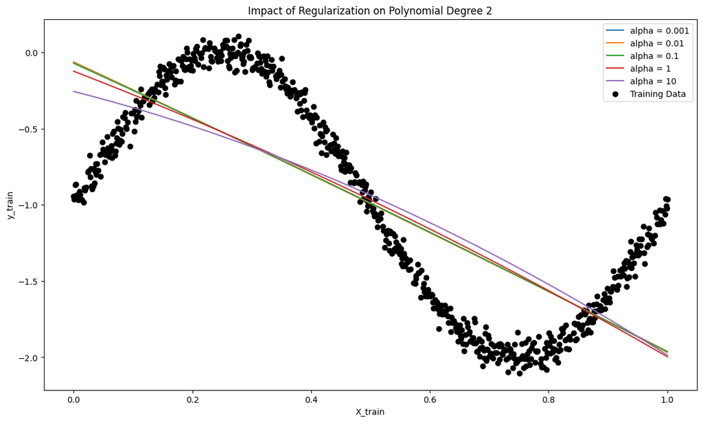

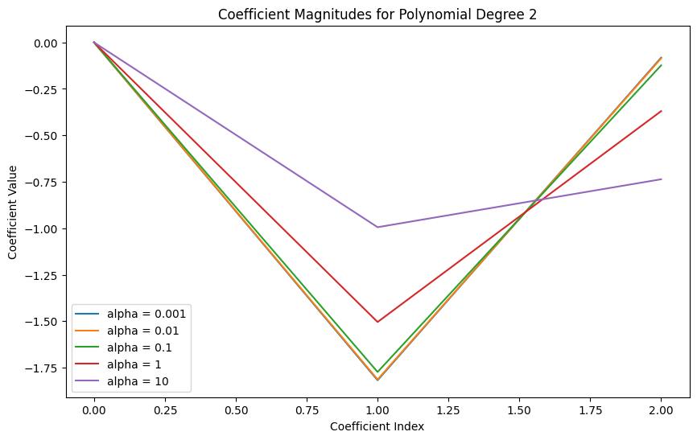

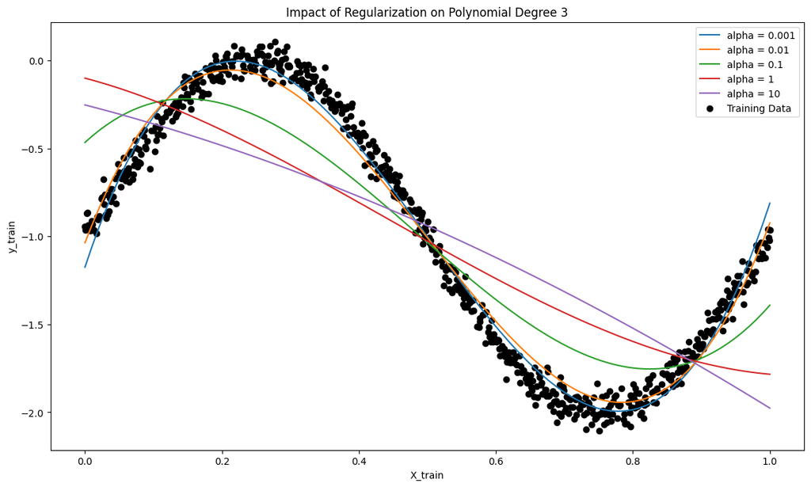

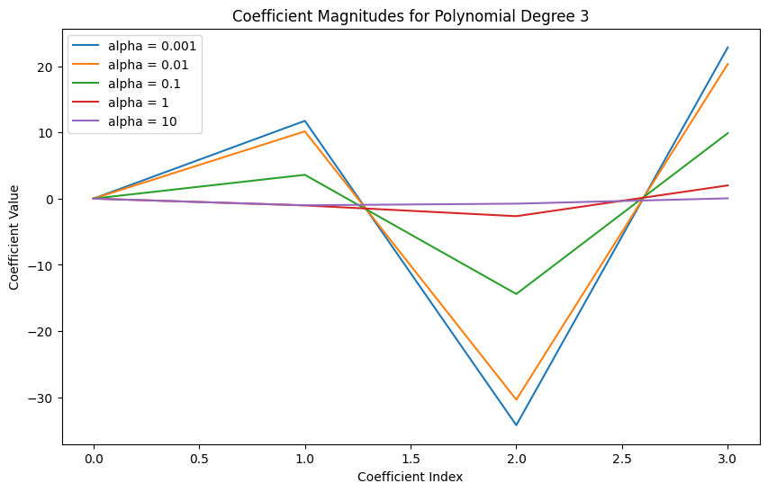

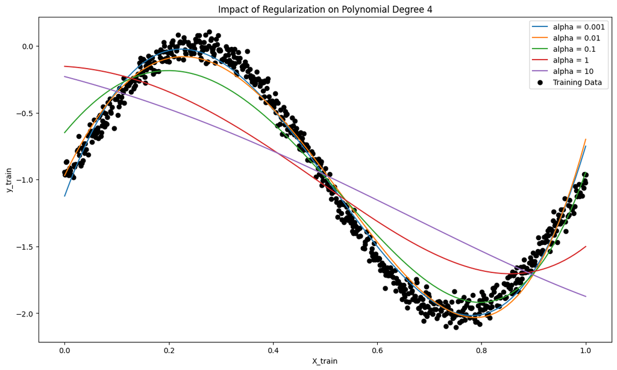

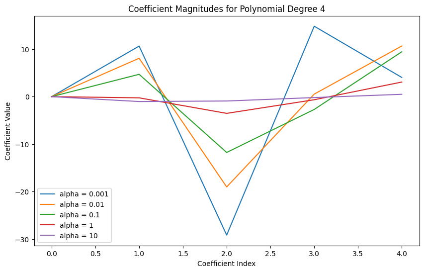

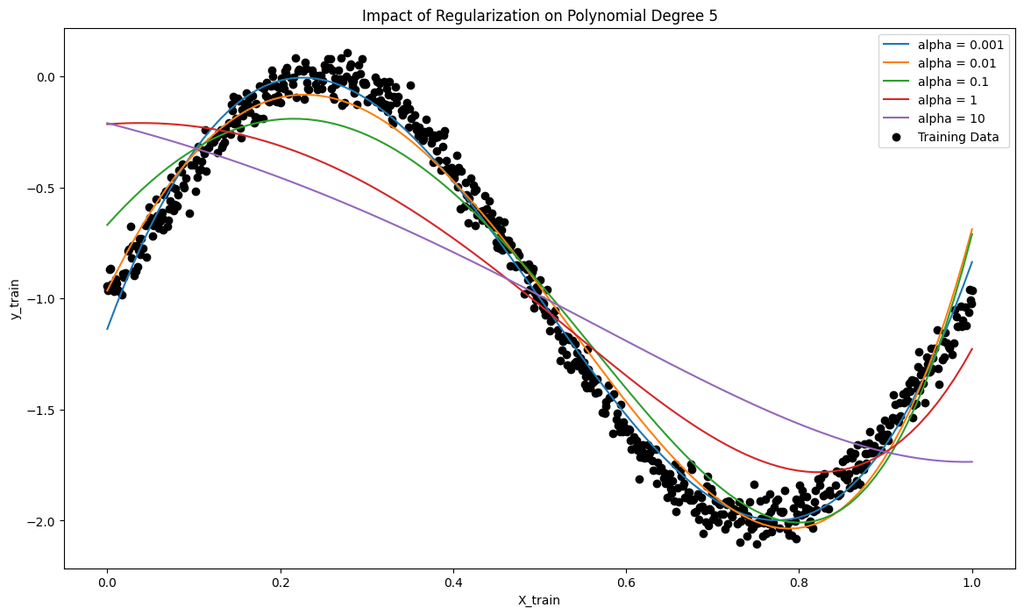

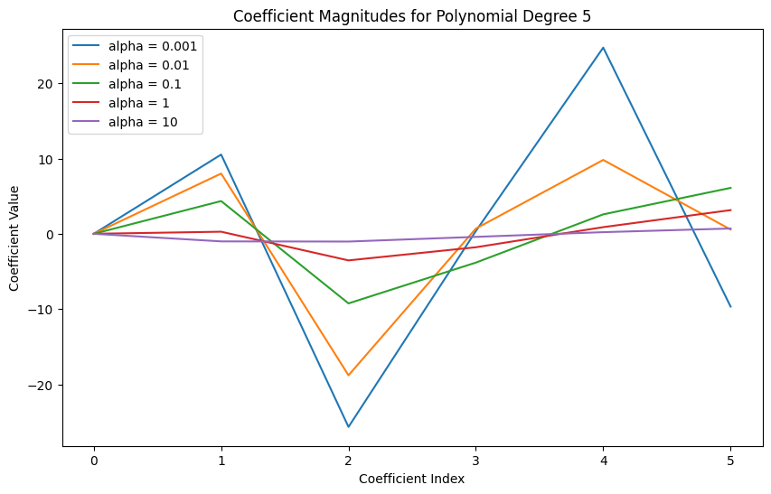

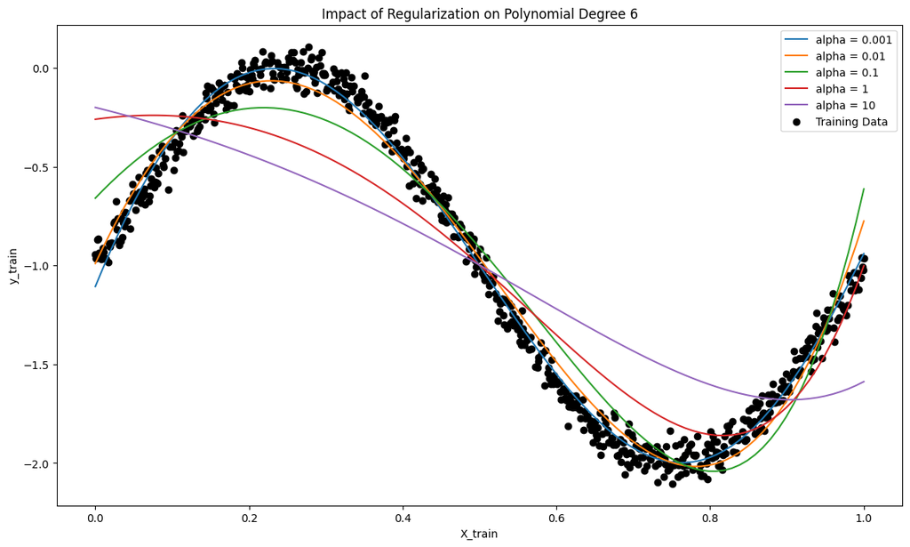

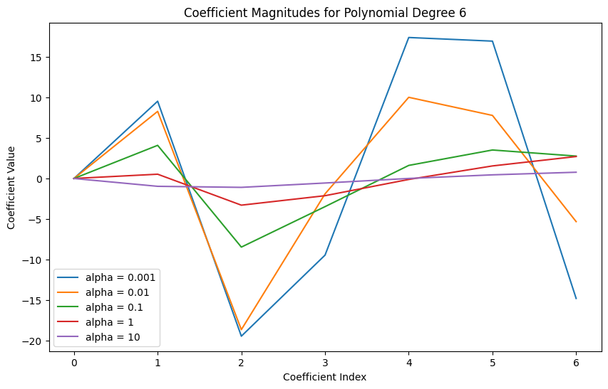

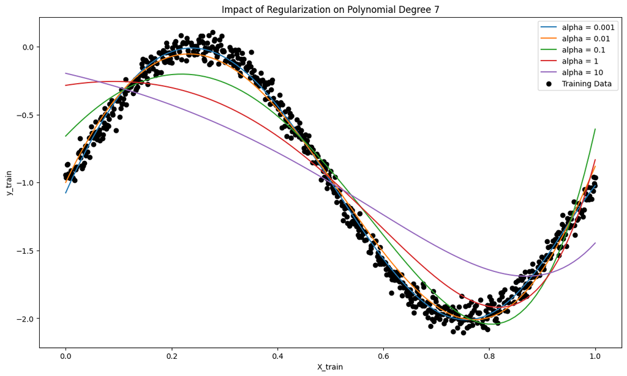

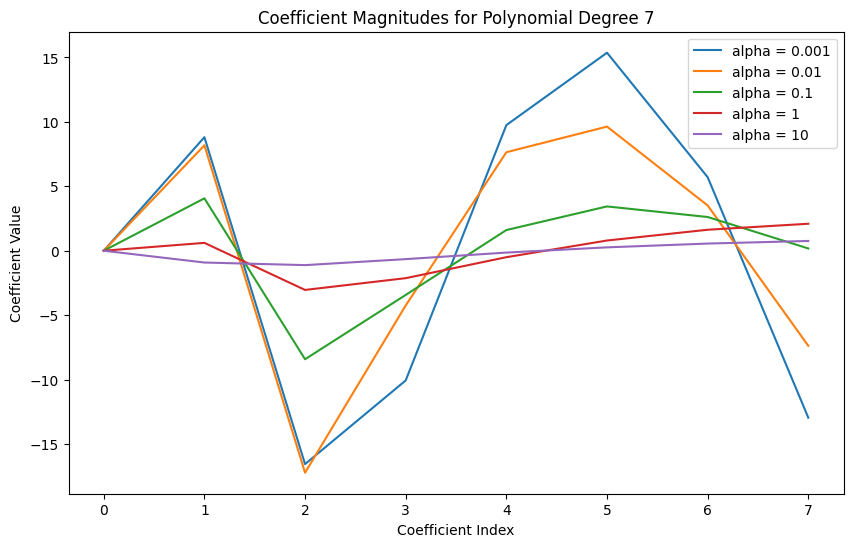

[4 more figures not shown]

```python
from sklearn.linear_model import Ridge

# Define regularization parameters
alphas = [0.001, 0.01, 0.1, 1, 10]

# Loop through polynomial degrees
for degree in degrees:
    plt.figure(figsize=(14, 8))
    plt.title(f"Impact of Regularization on Polynomial Degree {degree}")
    plt.xlabel("X_train")
    plt.ylabel("y_train")

    # Transform data to polynomial features for the current degree
    poly = PolynomialFeatures(degree=degree)
    X_train_poly = poly.fit_transform(X_train_full)

    # Store coefficients for plotting
    coefficients = []

    # Loop through each regularization parameter alpha
    for alpha in alphas:
        # Initialize and fit Ridge regression model with regularization parameter alpha
        ridge_model = Ridge(alpha=alpha)
        ridge_model.fit(X_train_poly, y_train_full)

        # Predict for a smooth curve across the range of X values
        X_range = np.linspace(X_train_full.min(), X_train_full.max(), 100).reshape(-1, 1)
        X_range_poly = poly.transform(X_range)
        y_pred = ridge_model.predict(X_range_poly)

        # Record model coefficients for visualization
        coefficients.append(ridge_model.coef_)

        # Plot the fitted polynomial curve
        plt.plot(X_range, y_pred, label=f'alpha = {alpha}')

    # Plot training data points
    plt.scatter(X_train_full, y_train_full, color='black', label="Training Data")
    plt.legend()
    plt.show()

    # Plot coefficients for each alpha
    coefficients = np.array(coefficients)
    plt.figure(figsize=(10, 6))
    for i, alpha in enumerate(alphas):
        plt.plot(range(len(coefficients[i])), coefficients[i], label=f'alpha = {alpha}')

    plt.title(f'Coefficient Magnitudes for Polynomial Degree {degree}')
    plt.xlabel('Coefficient Index')
    plt.ylabel('Coefficient Value')
    plt.legend()
    plt.show()
```

1. **Regularization with Ridge Regression**:
   - For each polynomial degree from `2` to `9`, Ridge regression is applied with varying regularization strengths, defined by `alpha` values (0.001, 0.01, 0.1, 1, and 10). These values control the regularization effect, where smaller values mean less regularization, and larger values impose stronger regularization, reducing the magnitude of the polynomial coefficients.
2. **Fitting Polynomial Models**:
   - For each polynomial degree, we first transform the training data `X_train_full` to polynomial features using `PolynomialFeatures`. This enables us to fit polynomial models of increasing complexity, capturing non-linear relationships as the polynomial degree increases.
3. **Recording Model Coefficients**:
   - For each regularization parameter (alpha value), we store the fitted model’s coefficients after transforming the features. Ridge regularization penalizes high-magnitude coefficients, so observing how coefficients change for different alpha values and polynomial degrees provides insight into regularization’s effect on model complexity.
4. **Plotting the Fitted Curves**:
   - For each polynomial degree, we generate a plot showing the polynomial fits across different values of `alpha` on the same plot as the training data. The visual comparison of these curves allows us to see how the model complexity changes with increasing regularization strength.
5. **Plotting Coefficient Magnitudes**:
   - A second plot shows the model coefficients for each alpha, allowing us to observe how increasing alpha reduces coefficient values, particularly for higher polynomial degrees. By examining this plot, we can see how the regularization strength (alpha) affects each model’s flexibility and tendency to overfit.

### Inferences

1. **Trade-Off Between Bias and Variance**:
   - Regularization effectively balances the bias-variance trade-off. Lower alpha values allow the model to fit more complex patterns, which may lead to overfitting (high variance). Higher alpha values reduce variance but increase bias, as the model becomes overly simplistic and less flexible.
2. **Choosing an Appropriate Alpha**:
   - An optimal alpha value minimizes the error on unseen data by balancing flexibility and generalization. Cross-validation can help identify this optimal alpha value, ensuring the model captures the underlying pattern without fitting noise.
3. **Effectiveness of Regularization for High-Degree Polynomials**:
   - Regularization is especially valuable for higher-degree polynomials, where overfitting is more likely. By penalizing large coefficients, regularization forces the model to focus on significant patterns, reducing the risk of overfitting.

In conclusion, regularization allows polynomial models to capture essential data patterns while preventing the excessive complexity that leads to overfitting. The visualizations demonstrate that choosing the right alpha value and degree can significantly improve model generalization.

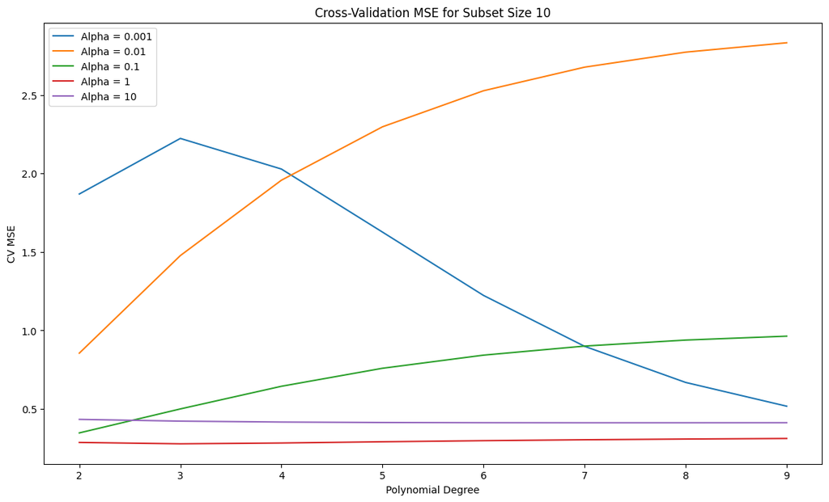

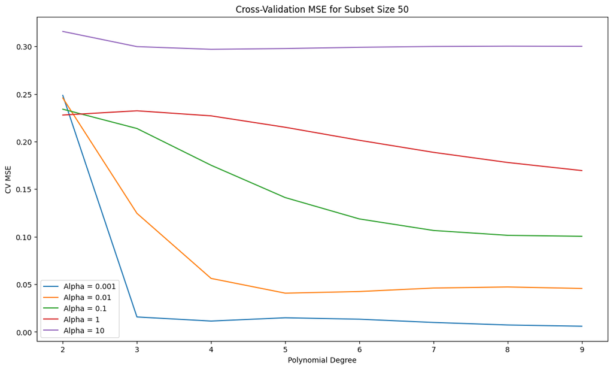

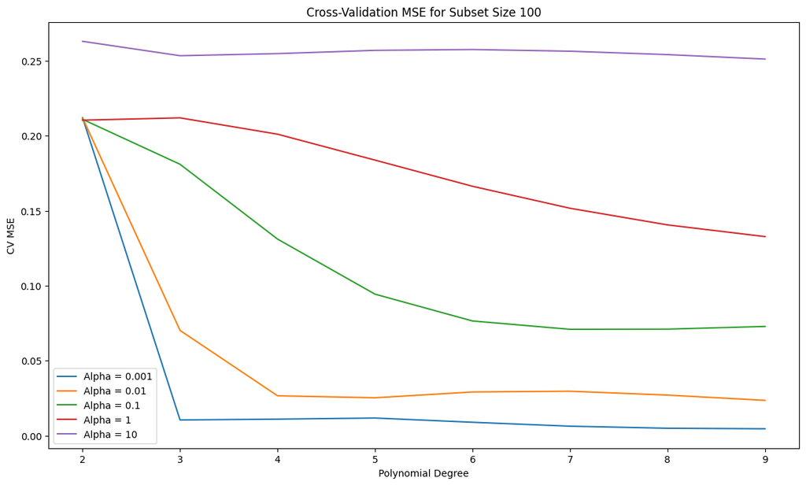

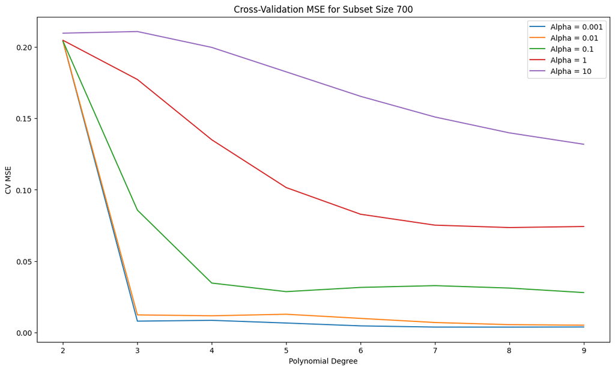

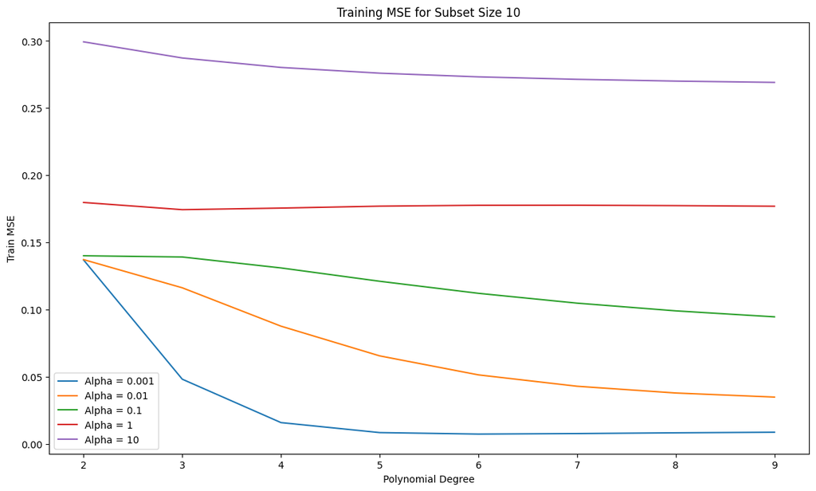

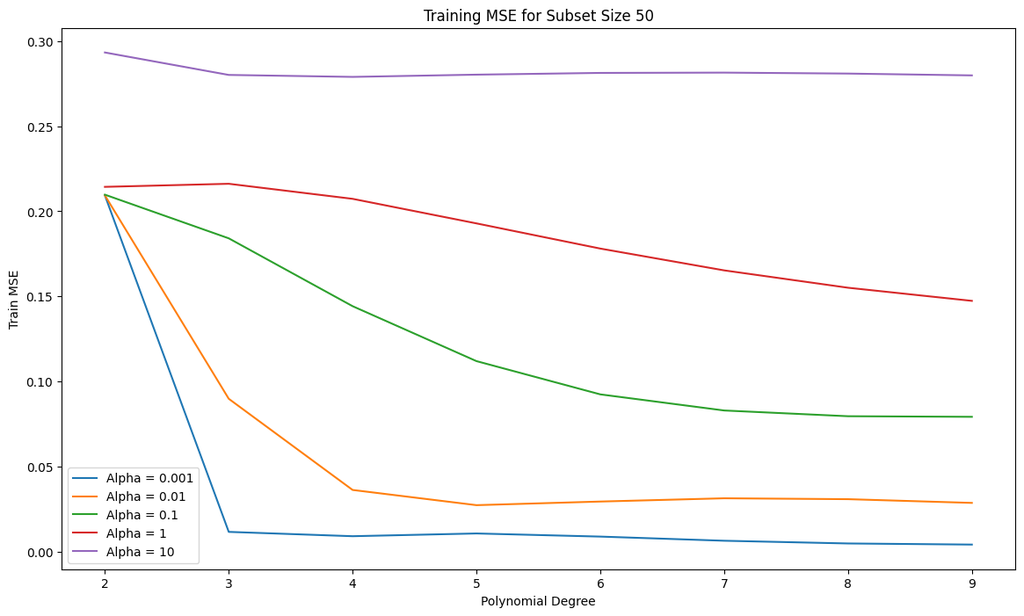

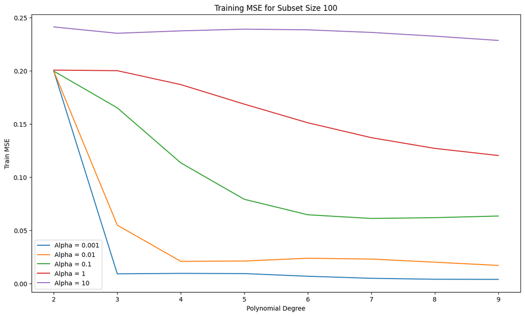

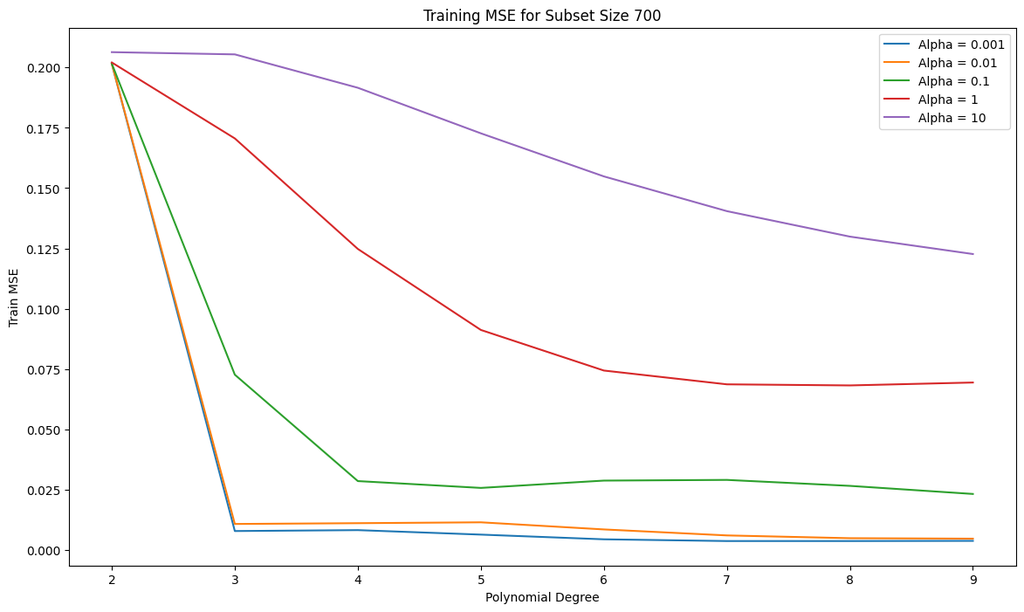

```python
from sklearn.model_selection import cross_val_score
from sklearn.metrics import mean_squared_error

# Define storage for results
mse_train_results = []
mse_cv_results = []

# Loop through subset sizes
for size in subset_sizes:
    # Sample the training data to create a subset
    X_train_subset = X_train_full[:size]
    y_train_subset = y_train_full[:size]

    # Loop through polynomial degrees
    for degree in degrees:
        # Transform data to polynomial features for the current degree
        poly = PolynomialFeatures(degree=degree)
        X_train_poly = poly.fit_transform(X_train_subset)

        # Loop through each regularization parameter alpha
        for alpha in alphas:
            # Initialize Ridge regression model with the current alpha
            ridge_model = Ridge(alpha=alpha)

            # Cross-validation: calculate the MSE on training data using cross-validation
            cv_mse = -cross_val_score(ridge_model, X_train_poly, y_train_subset, scoring='neg_mean_squared_error', cv=5).mean()

            # Store the training subset size, polynomial degree, alpha, and MSE
            mse_cv_results.append({
                'Subset Size': size,
                'Degree': degree,
                'Alpha': alpha,
                'CV MSE': cv_mse
            })

            # Fit the model on the subset data and compute MSE for training data
            ridge_model.fit(X_train_poly, y_train_subset)
            train_mse = mean_squared_error(y_train_subset, ridge_model.predict(X_train_poly))

            mse_train_results.append({
                'Subset Size': size,
                'Degree': degree,
                'Alpha': alpha,
                'Train MSE': train_mse
            })

# Convert results to DataFrames for easy plotting
mse_train_df = pd.DataFrame(mse_train_results)
mse_cv_df = pd.DataFrame(mse_cv_results)

# Plotting MSE for different polynomial degrees and regularization values
for size in subset_sizes:
    plt.figure(figsize=(14, 8))
    subset_data = mse_cv_df[mse_cv_df['Subset Size'] == size]
    for alpha in alphas:
        alpha_data = subset_data[subset_data['Alpha'] == alpha]
        plt.plot(alpha_data['Degree'], alpha_data['CV MSE'], label=f'Alpha = {alpha}')

    plt.title(f'Cross-Validation MSE for Subset Size {size}')
    plt.xlabel('Polynomial Degree')
    plt.ylabel('CV MSE')
    plt.legend()
    plt.show()

# Plot MSE for Training Data for different polynomial degrees and regularization values
for size in subset_sizes:
    plt.figure(figsize=(14, 8))
    subset_data = mse_train_df[mse_train_df['Subset Size'] == size]
    for alpha in alphas:
        alpha_data = subset_data[subset_data['Alpha'] == alpha]
        plt.plot(alpha_data['Degree'], alpha_data['Train MSE'], label=f'Alpha = {alpha}')

    plt.title(f'Training MSE for Subset Size {size}')
    plt.xlabel('Polynomial Degree')
    plt.ylabel('Train MSE')
    plt.legend()
    plt.show()
```

### Explanation

1. **Cross-Validation MSE Calculation**:
   - For each combination of training subset size, polynomial degree, and regularization parameter (alpha), we use `cross_val_score` with 5-fold cross-validation to calculate the cross-validation Mean Squared Error (CV MSE). Cross-validation helps in assessing how well each model generalizes to unseen data by splitting the subset into training and validation folds.
   - By calculating CV MSE for each combination, we gather insight into which polynomial degree and alpha value yield the lowest error on validation data, indicating the best generalization performance.
2. **Training MSE Calculation**:
   - In addition to calculating CV MSE, we compute the training MSE (Train MSE) for each model. This MSE on the subset data shows the model’s accuracy on data it has seen, allowing us to compare training and cross-validation performance.
   - A significant discrepancy between Train MSE and CV MSE can signal overfitting (high accuracy on training but poor performance on validation), while consistently high errors on both could indicate underfitting (model too simple to capture underlying patterns).
3. **Storing and Converting Results**:
   - The results from each model configuration are stored in two lists, `mse_train_results` and `mse_cv_results`, which are then converted to pandas DataFrames (`mse_train_df` and `mse_cv_df`) for convenient access and plotting.
4. **Plotting Cross-Validation MSE**:
   - For each subset size, we create a plot of cross-validation MSE against polynomial degree, with lines for each alpha value. This helps visualize how model complexity (polynomial degree) and regularization (alpha) interact to impact error on validation data.
   - The goal is to find the degree and alpha combination that minimizes CV MSE, balancing model complexity and regularization to achieve the best fit.
5. **Plotting Training MSE**:
   - Similarly, for each subset size, we plot training MSE against polynomial degree, with separate lines for each alpha value. These plots highlight how training MSE changes with increasing polynomial degrees and varying alpha values, providing insight into the model’s accuracy on the training data and any potential overfitting.

### Observations

1. **Cross-Validation MSE Trends**:
   - **Low Alpha Values**: When alpha is low, higher-degree polynomials often have lower CV MSE, as they fit the data with high flexibility. However, in some cases, CV MSE starts increasing for high degrees, indicating overfitting, where the model becomes too complex and captures noise in the data.
   - **High Alpha Values**: With larger alpha values, CV MSE often stabilizes or increases as polynomial degree increases, indicating that regularization helps prevent overfitting by reducing the model’s flexibility, especially for high-degree polynomials.
2. **Training MSE Trends**:
   - **Low Alpha Values and High Degrees**: For low alpha values, training MSE decreases significantly with increasing polynomial degree, as the model captures more variance in the data. However, if training MSE is much lower than CV MSE, this suggests overfitting.
   - **High Alpha Values and Lower Degrees**: As alpha increases, training MSE becomes higher, indicating that regularization makes the model less flexible and thus more biased. The training MSE plots generally flatten at higher degrees for large alpha values, showing that regularization reduces the impact of added polynomial complexity.
3. **Effect of Subset Size**:
   - **Small Subsets**: For smaller subsets (e.g., size 10), the CV MSE is often higher across polynomial degrees, reflecting the challenge of generalizing with limited data. The effect of regularization is more pronounced, as high-degree polynomials tend to overfit smaller datasets without strong regularization.
   - **Larger Subsets**: As subset size increases (50, 100, full set), the CV MSE tends to decrease, and optimal polynomial degrees are more stable. The effect of regularization is less pronounced on larger datasets, as there is more data to learn meaningful patterns, even with higher-degree polynomials.

### Inferences

In conclusion, cross-validation reveals the importance of balancing model complexity with regularization to achieve the lowest error on unseen data. Selecting an optimal polynomial degree and alpha value minimizes the risk of overfitting while ensuring the model is sufficiently flexible to capture data patterns.

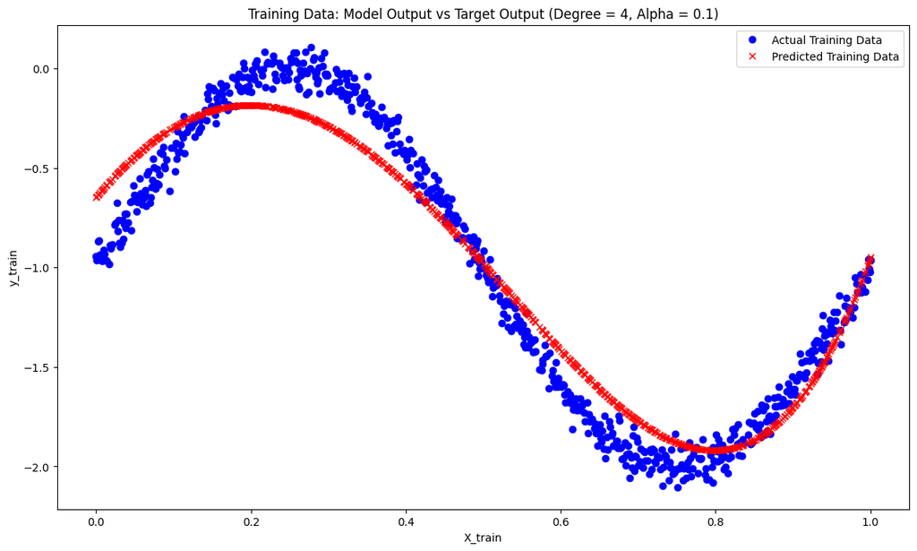

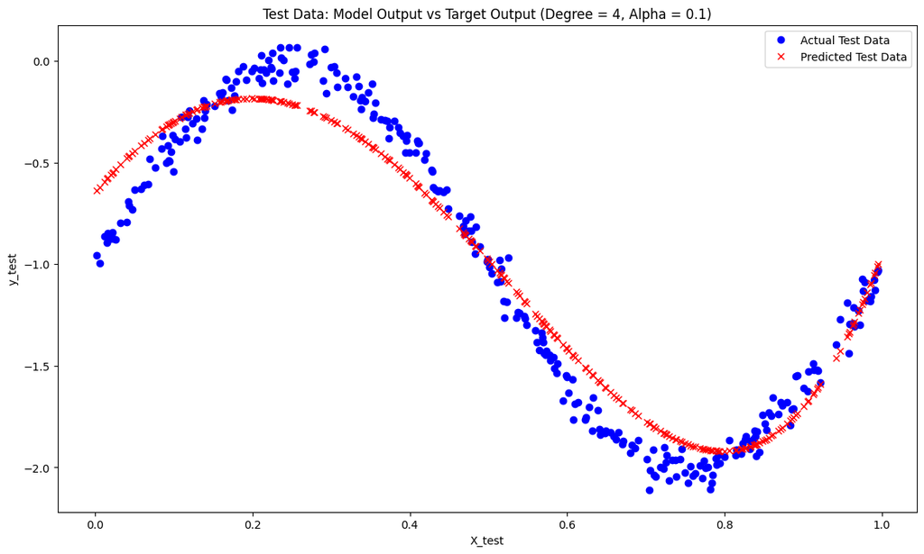

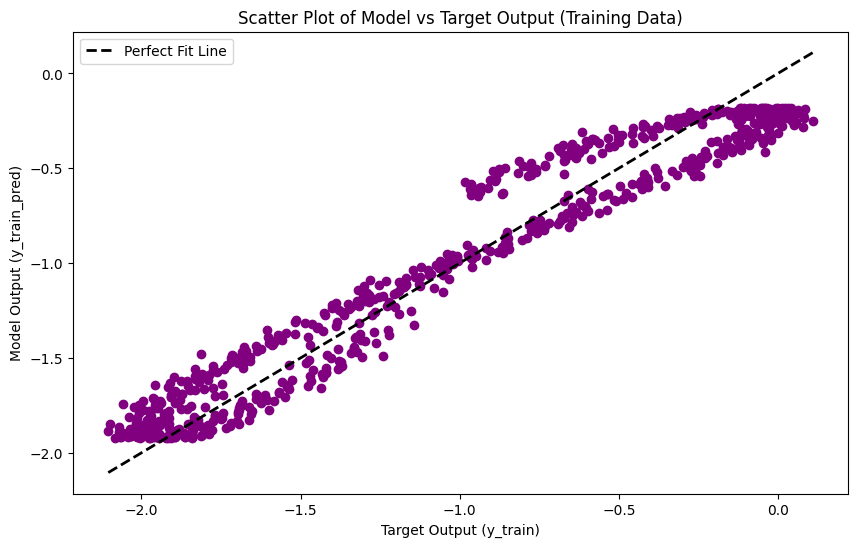

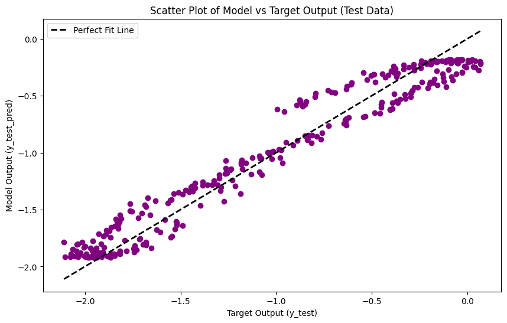

```python
# Assume the best polynomial degree and alpha are selected based on the lowest CV MSE
# Define the best polynomial degree and alpha (these values would typically be found programmatically)
best_degree = 4  # Example value, replace with the best degree found in cross-validation
best_alpha = 0.1  # Example value, replace with the best alpha found in cross-validation

# Transform data using the best polynomial degree
poly = PolynomialFeatures(degree=best_degree)
X_train_poly = poly.fit_transform(X_train_full)
X_test_poly = poly.transform(test_data['X_test'].values.reshape(-1, 1))

# Fit the best model on the training data
best_model = Ridge(alpha=best_alpha)
best_model.fit(X_train_poly, y_train_full)

# Predict values for both training and test datasets
y_train_pred = best_model.predict(X_train_poly)
y_test_pred = best_model.predict(X_test_poly)

# Plot Model Output vs Target Output for Training Data
plt.figure(figsize=(14, 8))
plt.plot(X_train_full, y_train_full, 'o', label='Actual Training Data', color='blue')
plt.plot(X_train_full, y_train_pred, 'x', label='Predicted Training Data', color='red')
plt.title(f'Training Data: Model Output vs Target Output (Degree = {best_degree}, Alpha = {best_alpha})')
plt.xlabel('X_train')
plt.ylabel('y_train')
plt.legend()
plt.show()

# Plot Model Output vs Target Output for Test Data
plt.figure(figsize=(14, 8))
plt.plot(test_data['X_test'], test_data['y_test'], 'o', label='Actual Test Data', color='blue')
plt.plot(test_data['X_test'], y_test_pred, 'x', label='Predicted Test Data', color='red')
plt.title(f'Test Data: Model Output vs Target Output (Degree = {best_degree}, Alpha = {best_alpha})')
plt.xlabel('X_test')
plt.ylabel('y_test')
plt.legend()
plt.show()

# Scatter Plot: Target Output vs Model Output for Training Data
plt.figure(figsize=(10, 6))
plt.scatter(y_train_full, y_train_pred, color='purple')
plt.plot([y_train_full.min(), y_train_full.max()], [y_train_full.min(), y_train_full.max()], 'k--', lw=2, label="Perfect Fit Line")
plt.title(f'Scatter Plot of Model vs Target Output (Training Data)')
plt.xlabel('Target Output (y_train)')
plt.ylabel('Model Output (y_train_pred)')
plt.legend()
plt.show()

# Scatter Plot: Target Output vs Model Output for Test Data
plt.figure(figsize=(10, 6))
plt.scatter(test_data['y_test'], y_test_pred, color='purple')
plt.plot([test_data['y_test'].min(), test_data['y_test'].max()], [test_data['y_test'].min(), test_data['y_test'].max()], 'k--', lw=2, label="Perfect Fit Line")
plt.title(f'Scatter Plot of Model vs Target Output (Test Data)')
plt.xlabel('Target Output (y_test)')
plt.ylabel('Model Output (y_test_pred)')
plt.legend()
plt.show()
```